# EMC Conducted Emissions Test

The goal of this test is to see the impact of the EMI filter on the conducted emissions of the DC‑DC converter.  
Since we don't have a professional EMI receiver, the idea is to use an isolated oscilloscope powered by a 12V battery, and to use a Python package that we already developed and validated to emulate an EMC receiver.  
For more details about this EMI emulator, you can see the [PyPi page](https://pypi.org/project/emi-receiver/PyPi) or the github page of this project.  
The available oscilloscope for this test is the Tektronix TDS3034B, which has a limited memory depth of 10k points.  
To have a longer signal, the idea is to perform many acquisitions using a Python script (for more details see **EMI_saving_1CH.py**). We chose a horizontal resolution of 20 µs/div, and with 10k points the sampling time is 20 ns (50 MS/s), giving a recorded duration of 200 µs per shot. We will perform 50 shots each time, resulting in a total measurement time of 10 ms.  
No trigger is configured—each shot is taken randomly to avoid any bias in the measurement.  
After each measurement, we use the Python EMI‑receiver emulator to preprocess the signal and estimate AVG, PEAK, and QPEAK.

**Limitations of this test**

- No EMI receiver, but the oscilloscope coupled with Python code gives satisfying results.
- No conventional setup, but using a metallic ground plane and a 5 µH LISN approximates the standard setup.
- This test is not intended for absolute measurements (like comparing the results to standard limits). It is only intended to compare the “before” and “after” of each modification. Absolute measurements may not be very accurate, but we hope that the delta will be accurate enough.

## Test setup

[figure not shown]

**Figure 1:** Setup schematic

The setup is composed of a power supply (345V–405V, 800W) fixed to 380V as the nominal voltage, a LISN of two phases of 5 µH, the DCDC converter, a secondary load of 27 Ω, the oscilloscope, and its battery to ensure isolation.

- The DCDC and the load are placed on top of an insulating polystyrene layer of around 2 cm. The output voltage is regulated to 42V. We chose a low voltage to avoid under‑resonance issues since the current software is not the final version. With this configuration, we will have around 70 W at the output, which is enough to observe the DCDC noise.
- The DCDC is placed on top of two fans powered by its internal flyback, and it is grounded to the aluminum plane using two ground braids.
- The LISN is also grounded to the aluminum plane using its ground braid.
- The oscilloscope is isolated using several polystyrene layers to minimize the parasitic capacitance.
- The load and all wires are placed in the top of the polystyrene layer to reduce the parasite capacitor with ground

[figure not shown]

**Figure 2:** full setup

[figure not shown]

**Figure 3:** full setup, load

[figure not shown]

**Figure 4:** grounds of the dcdc and the LISN

[figure not shown]

**Figure 5:** LISN and power supply

[figure not shown]

**Figure 6:** 5µH LISN schematic

## EMI Filter Schematic Reminder

Below is a reminder of the proposed schematic of the EMI filter. Only one change has been made: the C50 capacitor of the differential snubber is 15 nF instead of 2.2 nF.

[figure not shown]

**Figure 7:** The main EMI filter schematic

Below the position of the 5 ceramic-y capacitors.

[figure not shown]

**Figure 8:** Ceramic y-caps 1nF

## Common-mode and Differential-mode Separation

[figure not shown]

**Figure 9:** Magnetic core of TCP0150 (common mode)

[figure not shown]

**Figure 10:** Common mode and differential mode measurement method

Below are the formulas used to convert the measured voltage into the estimated common‑mode and differential‑mode currents.

$ \begin{aligned} i_{cm} &= \left( \left( \frac{ \mathrm{Channel}_{Voltage} }{ R_{Terminal} } \right) \cdot \mathrm{Nturns} \right) \\[10pt] i_{dm} &= \frac{ \left( \frac{ \mathrm{Channel}_{Voltage} }{ R_{Terminal} } \right) \cdot \mathrm{Nturns} }{ 2 } \end{aligned} $

A zoom plot of both estimated currents

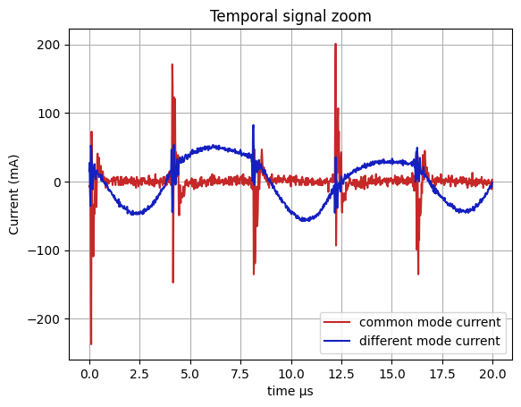

Below is an estimation of the reflected resistor using this setup. We can see that **2 Ω is a high value**, so using the oscilloscope’s **50 Ω input** as the load of the current transformer is a bad idea. Next time, we must add a **low external load**, such as **1 Ω**, so the reflected resistance on the primary will be only **40 mΩ**.

$ \begin{aligned} R_{Terminal} &= 50 \; \;\textrm{(Ω)} \\[10pt] N_{turns} &= 5 \; \\[10pt] R_{reflected} &= \frac{ R_{Terminal} }{ \left( N_{turns} \right) ^{ 2 } } = \frac{ 50 }{ \left( 5 \right) ^{ 2 } } &= 2.000 \; \;\textrm{(Ω)} \end{aligned} $

## HVP HVN, Vin 380V, Before using input filter

[figure not shown]

**Figure 11:** PCB: Input filter zone

### HVP & HVN Q-Peak

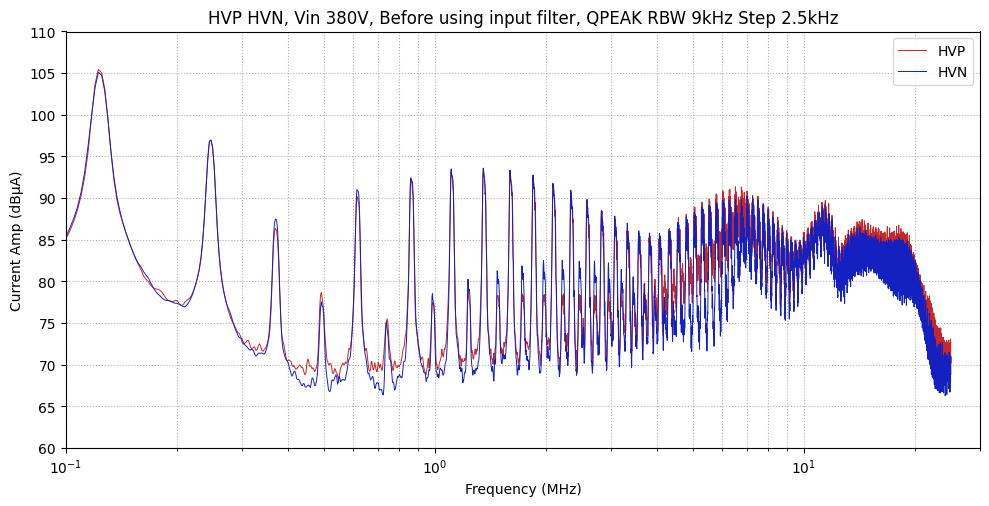

### HVP Q-Peak, Peak and AVG

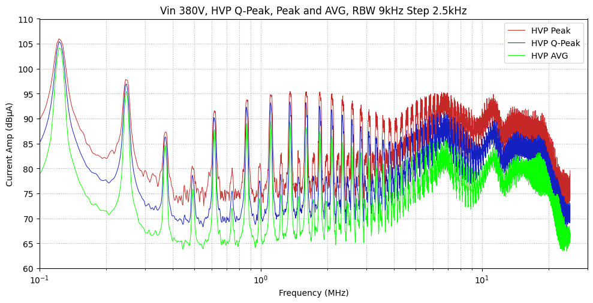

### HVN Q-Peak, Peak and AVG

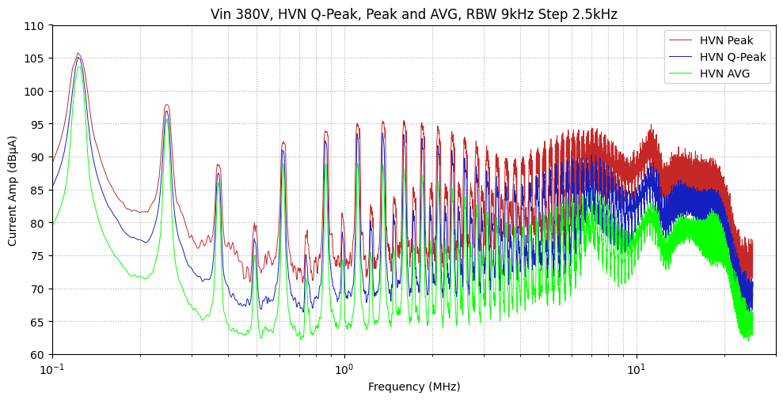

## Common Mode Choke (CMC) impact

[figure not shown]

**Figure 12:** Before

[figure not shown]

**Figure 13:** After

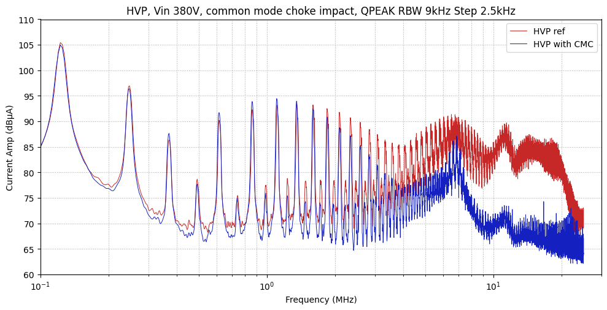

## Adding film capacitors and snubber

[figure not shown]

**Figure 14:** Before

[figure not shown]

**Figure 15:** After

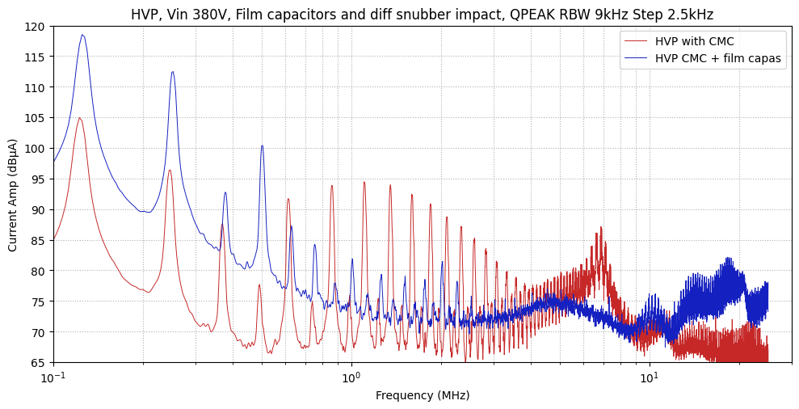

## Adding ceramic y-capacitors

[figure not shown]

**Figure 16:** The Y-ceramic capacitors are circled in red

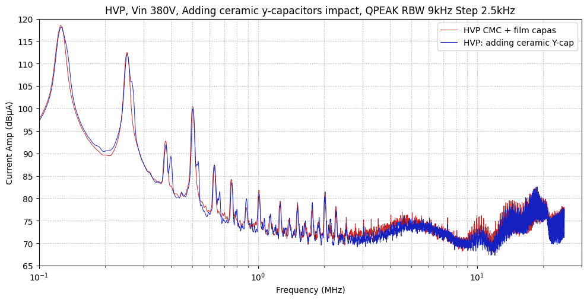

## Try differential snubber 220nF and 2.4 ohm

[figure not shown]

**Figure 17:** The prototype of a differential-mode snubber (0.22 µF & 2.4 Ω) is circled in red

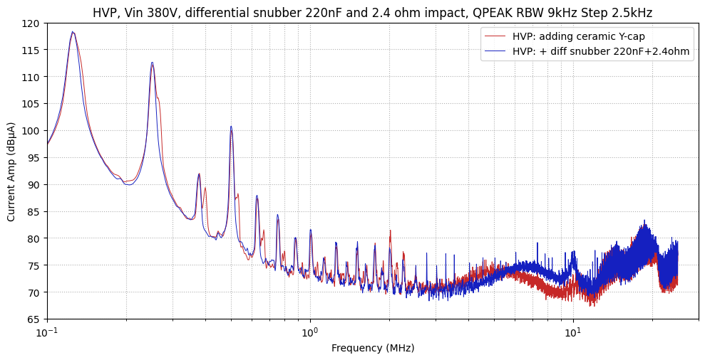

## Try common mode snubber 4.7nF and 360 ohm

[figure not shown]

**Figure 18:** The prototype of a common-mode snubber (4.7 nF & 360 Ω) is circled in red

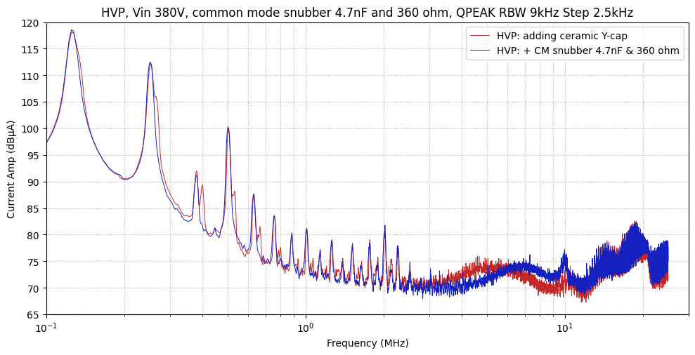

## EMC measurement with and without EMI filter

### HVP and HVN Q-Peak after using the EMI filter

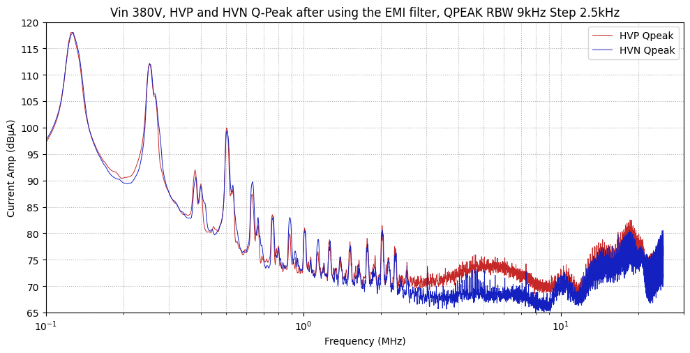

### HVP Q-Peak, Peak and AVG, after using EMI filter

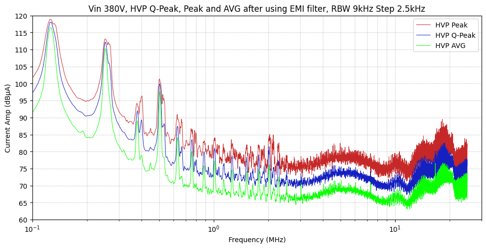

### HVN Q-Peak, Peak and AVG, after using EMI filter

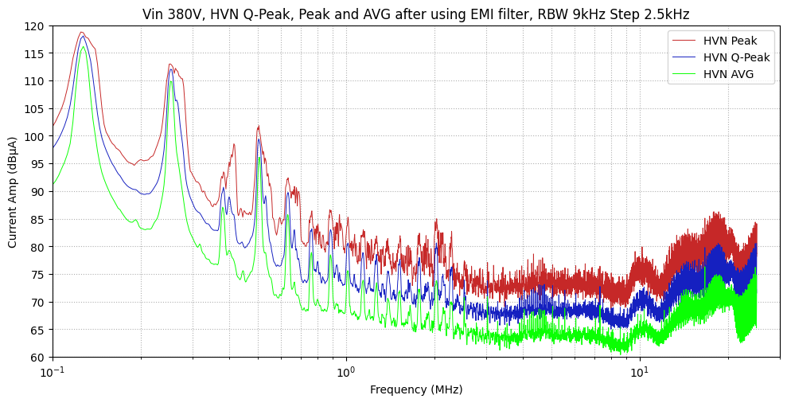

### HVP Q-PEAK before vs after using EMI filter

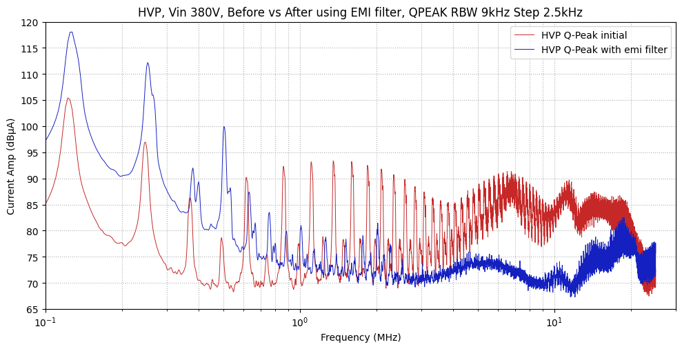

## Annexes

### Main power supply noise

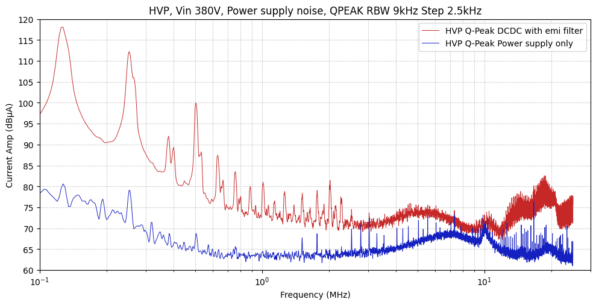

### FlyBack noise

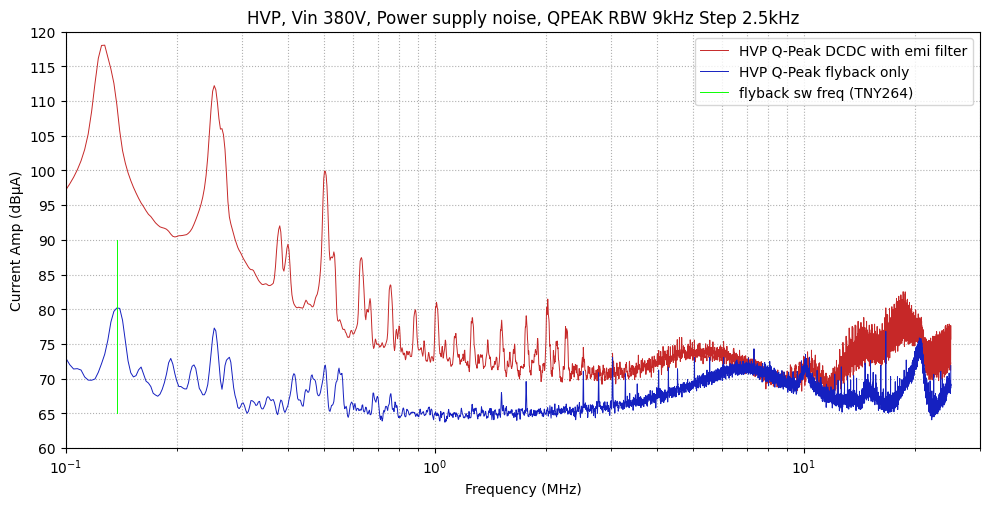

### EMI impact of Gate driver resistor (Rg)

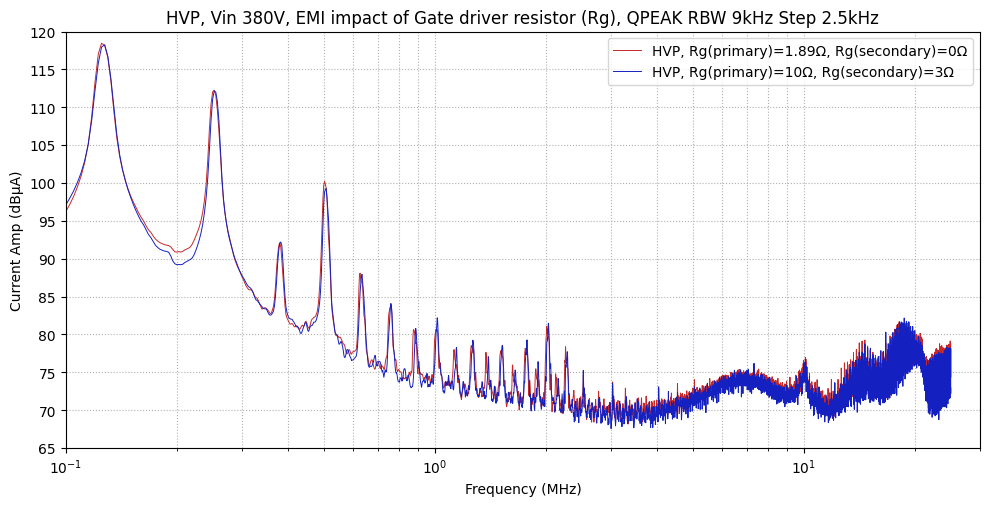

### Common-mode and Differential-mode Separation (Math)

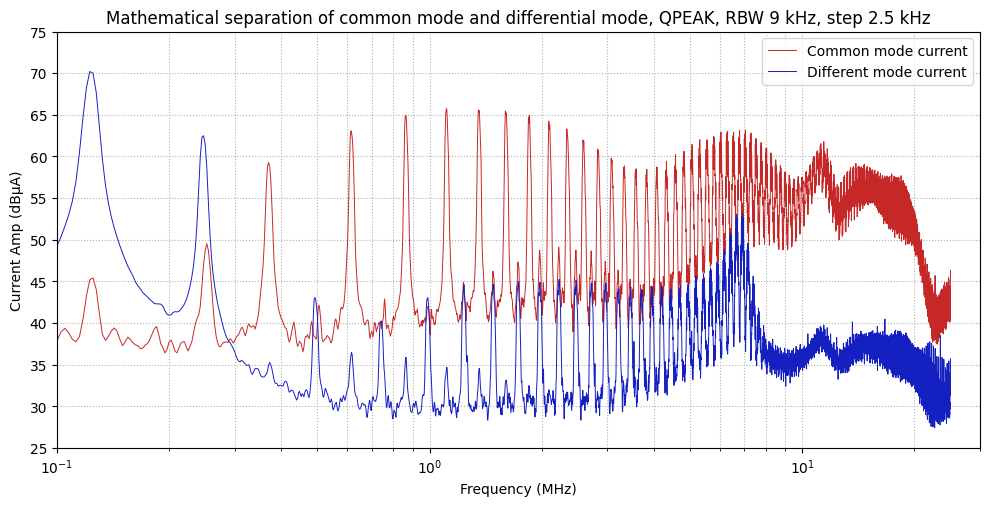